# Decision Tree Algorithm

Decision Tree is one of the most commonly used, practical approaches for supervised learning. It can be used to solve both Regression and Classification tasks with the latter being put more into practical application.

It is a tree-structured classifier with three types of nodes. The Root Node is the initial node which represents the entire sample and may get split further into further nodes. The Interior Nodes represent the features of a data set and the branches represent the decision rules. Finally, the Leaf Nodes represent the outcome. This algorithm is very useful for solving decision-related problems.

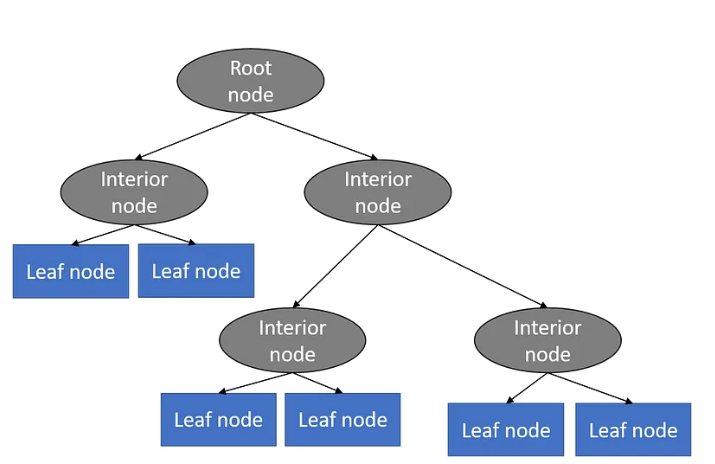

With a particular data point, it is run completely through the entirely tree by answering True/False questions till it reaches the leaf node. The final prediction is the average of the value of the dependent variable in that particular leaf node. Through multiple iterations, the Tree is able to predict a proper value for the data point.

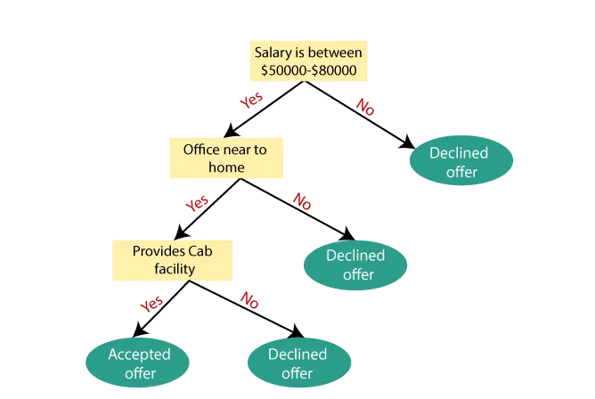

The above diagram is a representation for the implementation of a Decision Tree algorithm. Decision trees have an advantage that it is easy to understand, lesser data cleaning is required, non-linearity does not affect the model’s performance and the number of hyper-parameters to be tuned is almost null. However, it may have an over-fitting problem, which can be resolved using the Random Forest algorithm

**In this example, we will go through the implementation of Decision Tree Regression, in which we will predict the revenue of an ice cream shop based on the temperature in an area for 500 days.**

# Problem Analysis

# Step 1: Importing the libraries

The first step will always consist of importing the libraries that are needed to develop the ML model. The NumPy, matplotlib and the Pandas libraries are imported.

```python
import numpy as np
import matplotlib.pyplot as plt
import pandas as pd
```

# Step 2: Importing the dataset

In this, we assign the independent variable (X) to the ‘Temperature’ column and the dependent variable (y) to the ‘Revenue’ column.

```python
dataset = pd.read_csv('IceCreamData.csv')
X = dataset['Temperature'].values
y = dataset['Revenue'].values

dataset.head(5)
```

|  | Temperature | Revenue |
| --- | --- | --- |
| 0 | 24.566884 | 534.799028 |
| 1 | 26.005191 | 625.190122 |
| 2 | 27.790554 | 660.632289 |
| 3 | 20.595335 | 487.706960 |
| 4 | 11.503498 | 316.240194 |

# Step 3: Splitting the dataset into the Training set and Test set

In the next step, we have to split the dataset as usual into the training set and the test set. For this we use test_size=0.05 which means that 5% of 500 data rows (25 rows) will only be used as test set and the remaining 475 rows will be used as training set for building the model.

```python
from sklearn.model_selection import train_test_split
X_train, X_test, y_train, y_test = train_test_split(X, y, test_size = 0.05)
```

# Step 4: Training the Decision Tree Regression model on the training set

We import the DecisionTreeRegressor class from sklearn.tree and assign it to the variable ‘regressor’. Then we fit the X_train and the y_train to the model by using theregressor.fit function. We use the reshape(-1,1) to reshape our variables to a single column vector.

```python
# Fitting Decision Tree Regression to the dataset
from sklearn.tree import DecisionTreeRegressor
regressor = DecisionTreeRegressor()
regressor.fit(X_train.reshape(-1,1), y_train.reshape(-1,1))
```

```
DecisionTreeRegressor()
```

# Step 5: Predicting the Results

In this step, we predict the results of the test set with the model trained on the training set values using the regressor.predict function and assign it to ‘y_pred’.

```python
y_pred = regressor.predict(X_test.reshape(-1,1))
y_pred
```

```
array([131.6570175, 691.5165411, 643.6486011, 478.5985086, 643.0909437,
       800.2024937, 381.8030138, 755.8183987, 550.4412717, 487.7069603,
       315.6465807, 456.524341 , 473.6043349, 819.1175879, 429.4357021,
       662.5589903, 258.2868099, 216.183462 , 190.7109408, 449.1128688,
       401.4330183, 319.3494624, 487.7069603, 501.7329901, 350.6290364])
```

# Step 6: Comparing the Real Values with Predicted Values

In this step, we shall compare and display the values of y_test as ‘Real Values’ and y_pred as ‘Predicted Values’ in a Pandas dataframe.

```python
df = pd.DataFrame({'Real Values':y_test.reshape(-1), 'Predicted Values':y_pred.reshape(-1)})
df
```

|  | Real Values | Predicted Values |
| --- | --- | --- |
| 0 | 71.160153 | 131.657017 |
| 1 | 731.598223 | 691.516541 |
| 2 | 581.074005 | 643.648601 |
| 3 | 505.743867 | 478.598509 |
| 4 | 695.851298 | 643.090944 |
| 5 | 828.296077 | 800.202494 |
| 6 | 322.983977 | 381.803014 |
| 7 | 685.654655 | 755.818399 |
| 8 | 520.853456 | 550.441272 |
| 9 | 477.841719 | 487.706960 |
| 10 | 367.940744 | 315.646581 |
| 11 | 448.930443 | 456.524341 |
| 12 | 454.189267 | 473.604335 |
| 13 | 857.526641 | 819.117588 |
| 14 | 448.471335 | 429.435702 |
| 15 | 641.025389 | 662.558990 |
| 16 | 228.901030 | 258.286810 |
| 17 | 223.435016 | 216.183462 |
| 18 | 195.735722 | 190.710941 |
| 19 | 477.295054 | 449.112869 |
| 20 | 385.672501 | 401.433018 |
| 21 | 306.090719 | 319.349462 |
| 22 | 425.012018 | 487.706960 |
| 23 | 441.508733 | 501.732990 |
| 24 | 362.515216 | 350.629036 |

From the above values, we infer that the model is able to predict the values of the y_test with a good accuracy.

# Step 7: Visualising the Decision Tree Regression Results

[figure not shown]

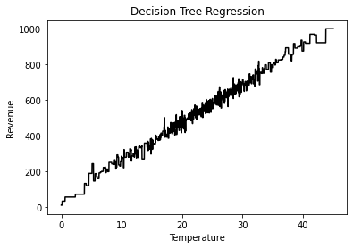

```python
# Visualising the Decision Tree Regression Results
X_grid = np.arange(min(X), max(X), 0.01)
X_grid = X_grid.reshape((len(X_grid), 1))
plt.scatter(X_test, y_test, color = 'red')
plt.scatter(X_test, y_pred, color = 'green')
plt.title('Decision Tree Regression')
plt.xlabel('Temperature')
plt.ylabel('Revenue')
plt.show()

plt.plot(X_grid, regressor.predict(X_grid), color = 'black')
plt.title('Decision Tree Regression')
plt.xlabel('Temperature')
plt.ylabel('Revenue')
plt.show()
```

In this graph, the Real values are plotted with “Red” color and the Predicted values are plotted with “Green” color. The plot of the Decision Tree Regression model is also drawn in “Black” color.